# DATA 612 - Summer 2020 - Project 1 | Global Baseline Predictors and RMSE

Bruno de Melo

June 6, 2020

# 1 Introduction - Random ratings

Back To Top

This recommender system is based on a random generated ratings. Technique used is **baseline predictor**.

Data set contains 10 users with ratings accross 20 items, but could be easily expanded to any size. It was extracted from:  
recommenderlab: A Framework for Developing and Testing Recommendation Algorithms, at http://citeseerx.ist.psu.edu/viewdoc/summary?doi=10.1.1.323.9961

# 2 Data Loading

First, I will generate a random 10x20 matrix in order to manually calculate averages, RMSE, biases and the baseline predictor.

```r
# seeding
set.seed(1234)

# random matrix
m<-matrix(sample(c(as.numeric(1:5), NA), 200, replace=TRUE, prob=c(rep(.4/2,5),.6)), ncol=20, dimnames=list(user=paste("u", 1:10, sep=''), item=paste("i", 1:20, sep='')))
m
```

```
##      item
## user  i1 i2 i3 i4 i5 i6 i7 i8 i9 i10 i11 i12 i13 i14 i15 i16 i17 i18 i19 i20
##   u1  NA  5 NA  3  4 NA  2 NA  1  NA  NA   5   5   1   4   3   3   2   3   5
##   u2   4  4 NA NA  5 NA NA  1  3   1   4  NA   1   5   1  NA   4   4  NA   1
##   u3   4 NA NA NA NA  5 NA NA NA  NA  NA   1   1  NA  NA  NA   3   5   4  NA
##   u4   4  1 NA  4  4  4 NA  2  4  NA  NA  NA   1   3   3   2  NA   3  NA   1
##   u5   2 NA NA NA NA NA NA NA NA  NA  NA  NA   3   1  NA  NA  NA  NA   1   2
##   u6   5  2  2  2  4  4  5  4  1   4  NA   1  NA   3   5   1   5   2  NA   2
##   u7  NA NA  4 NA  5  3 NA  3  3  NA  NA   1  NA   1   5   4   3   3   2   2
##   u8  NA NA  1 NA  3  2  4 NA NA  NA  NA  NA   4   4   4   1  NA   4   5   5
##   u9   5 NA  2  1 NA NA NA NA NA  NA   3  NA   3   5   1   3   2  NA  NA   1
##   u10  4 NA NA  2  2  2  4  5  1   5  NA   2  NA   2   4   4  NA  NA   5   5
```

# 3 Conversion to a User-Item Rating Matrix

```r
# coersing to realRatingMatrix type
r<-as(m,"realRatingMatrix")
class(r)
```

```
## [1] "realRatingMatrix"
## attr(,"package")
## [1] "recommenderlab"
```

This the user-item matrix dimension.

```r
r
```

```
## 10 x 20 rating matrix of class 'realRatingMatrix' with 117 ratings.
```

# 4 Exploratory Data Analysis

Exploring the dataset, plotting ratings distribution.

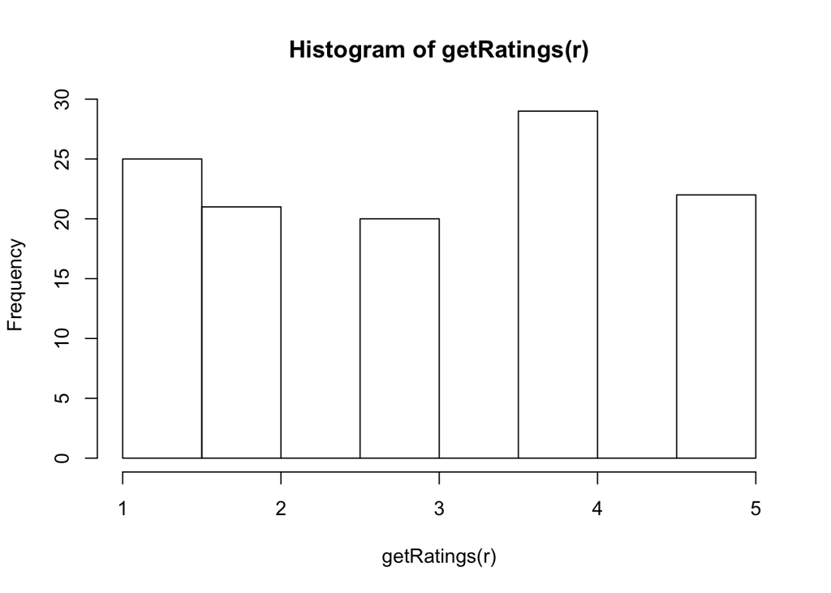

```r
hist(getRatings(r))
```

This is a rather balanced rating distribution.

Checking the ratings vector, to check number of missing ratings.

```r
vec_ratings<-as.vector(r@data)
(table_ratings<-table(vec_ratings))
```

```
## vec_ratings
##  0  1  2  3  4  5
## 83 25 21 20 29 22
```

As per the package documentation, a 0 rating represents a missing value.

Building a heatmap.

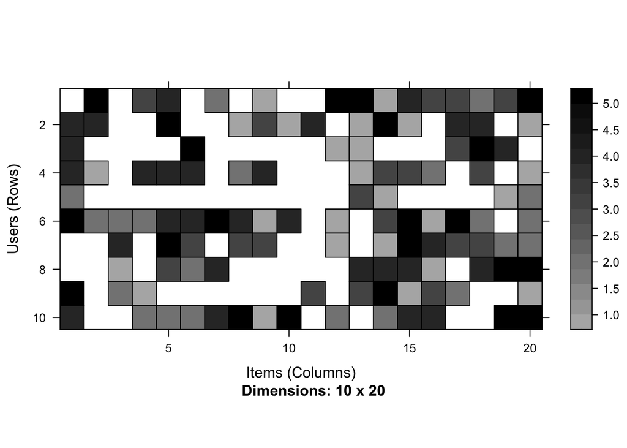

```r
image(r)
```

Most user have rated lots of items, only exception is perhaps user 5 with only 5 ratings.